# INFSCI 2595: Spring 2020: Weeks 7/8

Natural Splines

Dr. Joseph P. Yurko

## Overview

In week 07 of the course, we introduced linear basis function models via splines. This report goes into splines in a little more detail, primarily around with the spline basis. If you are interested to learn more about how the spline basis is constructed, please see Section 7.4 of the Introduction to Statistical Learning.

## Load libraries

This report primarily uses the `dplyr` and `ggplot2` libraries, which are loaded in the code chunk below. The `splines` library will also be used, but it will not be imported in directly. The `tidyr`package is also used for reshaping and reformating data sets, and lastly the `coefplot` package will be used to study `lm()` model results.

```r
library(dplyr)
```

```r
library(ggplot2)
```

## Synthetic data

As discussed in lecture, the spline basis is constructed relative to the input and **not** the response. We will use synthetic data to show that is indeed the case. We will be interested in modeling a sine wave, but we will use data generated from two different assumptions. In the first data set, 51 evenly spaced points between $-\pi$ and $+\pi$ are used. The second data set will have 51 randomly generated input values based on a normal distribution with mean 0 and standard deviation $\frac{\pi}{3}$. Can you figure out why this particular standard deviation was selected?

The two different input vectors are created in the code chunk below.

```r
x_even <- seq(-pi, pi, length.out = 51)

set.seed(61231)
x_norm <- rnorm(n = 51, mean = 0, sd = pi/3)
```

The two different input sets are compared below using a number line. Notice that the randomly generated data point are “bunched” together around the mean value of 0.

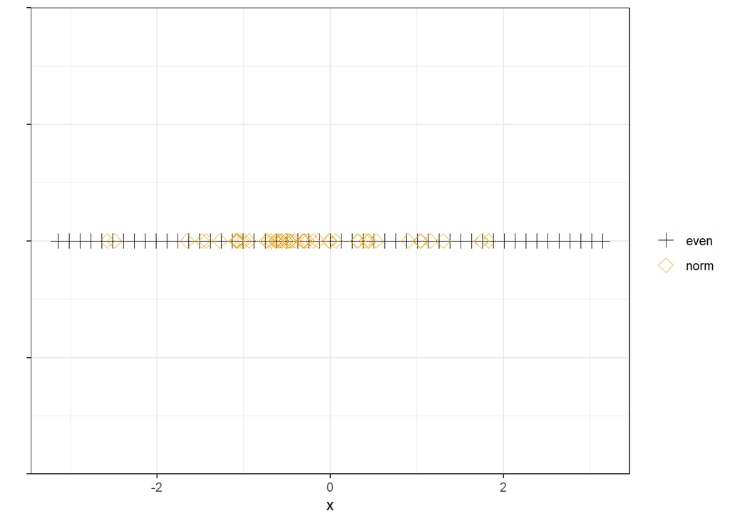

```r
tibble::tibble(x_even = x_even,
               x_norm = x_norm) %>%
  tibble::rowid_to_column() %>%
  tidyr::gather(key = "key", value = "value", -rowid) %>%
  tidyr::separate(key,
                  c("x_ltr", "type"),
                  sep = "_") %>%
  ggplot(mapping = aes(x = value, y = 0)) +
  geom_point(mapping = aes(color = type,
                           shape = type),
             size = 3) +
  ggthemes::scale_color_colorblind("") +
  scale_shape_manual("",
                     values = c("even" = 3,
                                "norm" = 5)) +
  labs(y = "", x = "x") +
  theme_bw() +
  theme(axis.text.y = element_blank())
```

### Natural spline basis

Let’s start out by generating a natural spline basis with 4 degrees-of-freedom. We can accomplish this with the `model.matrix()` and the `splines::ns()` functions. This approach mirrors using the `lm()` function to fit a spline model. Instead, we will go through the slightly more tedious approach of first generating the basis and then applying that basis to a data set.

We will start out by placing both the evenly spaced and randomly generated datasets into separate data.frames.

```r
even_df <- tibble::tibble(x = x_even)

norm_df <- tibble::tibble(x = x_norm)
```

Next, we will create the natural spline basis with 4 degrees-of-freedom using the evenly spaced data set. The `str()` function is used to display the “structure” of the `basis_even_04` object to the screen. Notice that the object has multiple attributes, one of which is referred to as the `"knots"`. The knots are interior input values or “locations” that are used to define the simple polynomials that will construct the basis. It might seem a little confusing, but the attributes provide a lot of information about the basis. The knots themselves are labeled or named to be `"25%"`, `"50%"`, and `"75%"`. This denotes that they correspond to the 0.25, 0.5, and 0.75 quantiles of the 51 evenly spaced `x` values. The `"Boundary.knots"` attribute provides the boundary values of the variable. As shown in the print out below, the boundary values are displayed to be `-3.14` and `3.14`, which corresponds to the bounds of the evenly spaced variable between $-\pi$ and $\pi$.

```r
basis_even_04 <- splines::ns(even_df$x, df = 4)

str(basis_even_04)
```

```
##  'ns' num [1:51, 1:4] 0.00 8.53e-05 6.83e-04 2.30e-03 5.46e-03 ...
##  - attr(*, "dimnames")=List of 2
##   ..$ : NULL
##   ..$ : chr [1:4] "1" "2" "3" "4"
##  - attr(*, "degree")= int 3
##  - attr(*, "knots")= Named num [1:3] -1.57 4.44e-16 1.57
##   ..- attr(*, "names")= chr [1:3] "25%" "50%" "75%"
##  - attr(*, "Boundary.knots")= num [1:2] -3.14 3.14
##  - attr(*, "intercept")= logi FALSE
```

The data type of `class()` of the `basis_even_04` object is shown below. It is a `"ns"` object, but is also considered to be a `"matrix"`. As shown in the `str()` result, the dimensionality of the object is 51 rows by 4 columns. Each column corresponds to a different curve associated with the basis. You can think of these columns as the features we are interested in studying in a model.

```r
class(basis_even_04)
```

```
## [1] "ns"     "basis"  "matrix"
```

The basis result contains almost everything we need from a modeling perspective. However, we will extract the knots and use those directly to create the design basis matrix associated with the natural spline with 4 degrees-of-freedom. The knots are extracts and assigned to the variable `knots_use_even_04` in the code chunk below.

```r
knots_use_even_04 <- as.vector(attributes(basis_even_04)$knots)
```

Now let’s go ahead and create the complete design basis matrix. In lecture we referred to basis design matrices as $\boldsymbol{\Phi}$-matrices. However in this report, we will denote them with captial X’s. The `model.matrix()` is used in conjuction with `splines::ns()` again, but this time the basis is defined with the `knots` argument, rather than the `df` argument. This forces the natural spline basis to be created based upon the specific `x` values associated with the knots. After the `Xmat_even_04` design matrix is created the first few rows of the matrix are printed to the screen.

```r
Xmat_even_04 <- model.matrix( ~ splines::ns(x, knots = knots_use_even_04), data = even_df)

Xmat_even_04 %>% head()
```

```
##   (Intercept) splines::ns(x, knots = knots_use_even_04)1
## 1           1                               0.000000e+00
## 2           1                               8.533333e-05
## 3           1                               6.826667e-04
## 4           1                               2.304000e-03
## 5           1                               5.461333e-03
## 6           1                               1.066667e-02
##   splines::ns(x, knots = knots_use_even_04)2
## 1                                 0.00000000
## 2                                -0.02024043
## 3                                -0.04022123
## 4                                -0.05968277
## 5                                -0.07836541
## 6                                -0.09600952
##   splines::ns(x, knots = knots_use_even_04)3
## 1                                 0.00000000
## 2                                 0.06072129
## 3                                 0.12066369
## 4                                 0.17904830
## 5                                 0.23509622
## 6                                 0.28802857
##   splines::ns(x, knots = knots_use_even_04)4
## 1                                 0.00000000
## 2                                -0.04048086
## 3                                -0.08044246
## 4                                -0.11936553
## 5                                -0.15673081
## 6                                -0.19201905
```

The `Xmat_even_04` matrix consists of `ncol(Xmat_even_04)` because the first column is the intercept column of 1’s. The names of the columns in the matrix are quite long, so the code chunk below simplifies the naming convention, by modifying the names with the `colnames()` function. After the name change, the first few rows are printed to the screen again.

```r
colnames(Xmat_even_04) <- c(colnames(Xmat_even_04)[1], sprintf("s_%02d", 1:ncol(basis_even_04)))

Xmat_even_04 %>% head()
```

```
##   (Intercept)         s_01        s_02       s_03        s_04
## 1           1 0.000000e+00  0.00000000 0.00000000  0.00000000
## 2           1 8.533333e-05 -0.02024043 0.06072129 -0.04048086
## 3           1 6.826667e-04 -0.04022123 0.12066369 -0.08044246
## 4           1 2.304000e-03 -0.05968277 0.17904830 -0.11936553
## 5           1 5.461333e-03 -0.07836541 0.23509622 -0.15673081
## 6           1 1.066667e-02 -0.09600952 0.28802857 -0.19201905
```

Each basis column or feature corresponds to a different polynomial curve. The features can be plotted with respect to the input `x` which helps us interpret what the features represent. To slow and tedious way to do this with `ggplot2` is to use a separate `geom_line()` call for each feature, as shown in the code chunk below.

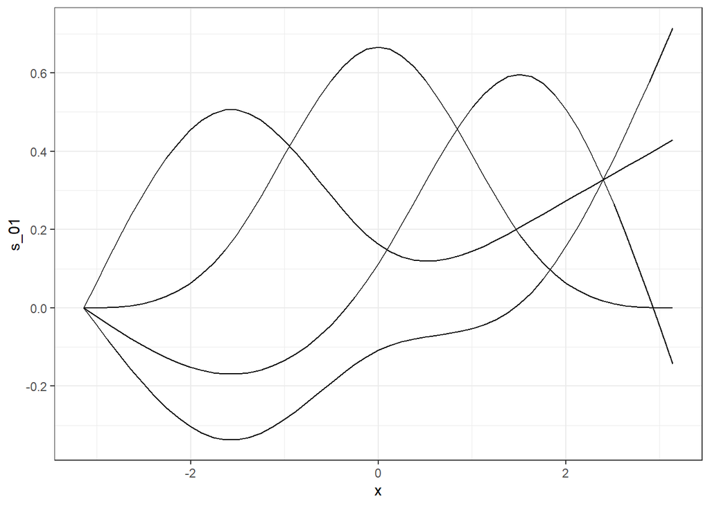

```r
even_df %>%
  bind_cols(Xmat_even_04 %>% as.data.frame() %>% tbl_df()) %>%
  ggplot(mapping = aes(x = x)) +
  geom_line(mapping = aes(y = s_01)) +
  geom_line(mapping = aes(y = s_02)) +
  geom_line(mapping = aes(y = s_03)) +
  geom_line(mapping = aes(y = s_04)) +
  theme_bw()
```

The “ggplot-way” to create this figure though is to reshape the design matrix from a “wide” to a “long” format. The “long” format will have fewer columns than the wide, with one variable storing the name of the feature and another column for the value of the feature. At first it might seem odd to structure the data in this manner, but long-formats can be quite useful, especially in working with time-series applications. The code chunk below shows how to merge the input with the design matrix and then reformat using the `tidyr::gather()` function. Think of “gathering” as “pulling” together many of the columns into a smaller number of columns. The new `key` column denotes the original variable names and the new `value` column is the value of the original variable. Any variables we do not wish to “gather” together can be listed with `-` before their names within the `tidyr::gather()` call. The “gathered” data set is stored to the object `even_basis_04_lf`. The `glimpse()` of the object is printed to the screen to show the dimensions and the names of the variables. The `(Intercept)` column was removed from the design matrix before the reformating to long-format. The intercept column is just a column of 1’s, so we will ignore it for plotting purposes.

```r
even_basis_04_lf <- even_df %>%
  bind_cols(Xmat_even_04 %>%
              as.data.frame() %>%
              tbl_df()) %>%
  select(-`(Intercept)`) %>%
  tibble::rowid_to_column() %>%
  tidyr::gather(key = "feature_name",
                value = "feature_value",
                -rowid, -x)

even_basis_04_lf %>% glimpse()
```

```
## Observations: 204
## Variables: 4
## $ rowid         <int> 1, 2, 3, 4, 5, 6, 7, 8, 9, 10, 11, 12, 13, 14, 1...
## $ x             <dbl> -3.1415927, -3.0159289, -2.8902652, -2.7646015, ...
## $ feature_name  <chr> "s_01", "s_01", "s_01", "s_01", "s_01", "s_01", ...
## $ feature_value <dbl> 0.000000e+00, 8.533333e-05, 6.826667e-04, 2.3040...
```

The `even_basis_04_lf` dataset consists of 204 rows because the 51 observations associated with each of the 4 spline features were stacked on top of each other.

We can now plot the features with `ggplot2` by mapping the `color` aesthetic to the `feature_name` variable. `ggplot2` will take care of labeling the legend for us.

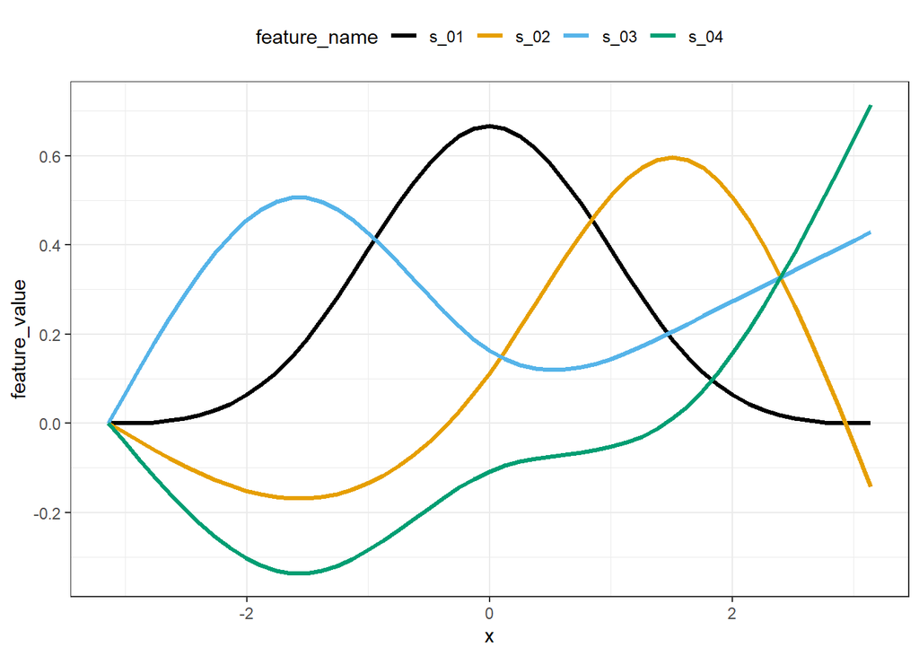

```r
even_basis_04_lf %>%
  ggplot(mapping = aes(x = x, y = feature_value)) +
  geom_line(mapping = aes(color = feature_name),
            size = 1.15) +
  ggthemes::scale_color_colorblind() +
  theme_bw() +
  theme(legend.position = "top")
```

It’s also easier to include the individual obserations as markers with `geom_point()` since we have the features in a long-format. It just requires adding one more layer to the graph.

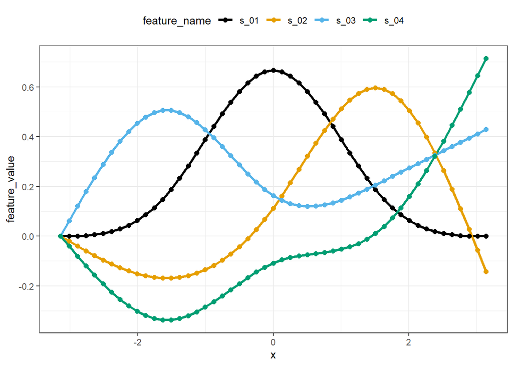

```r
even_basis_04_lf %>%
  ggplot(mapping = aes(x = x, y = feature_value)) +
  geom_line(mapping = aes(color = feature_name),
            size = 1.15) +
  geom_point(mapping = aes(color = feature_name),
             size = 2) +
  ggthemes::scale_color_colorblind() +
  theme_bw() +
  theme(legend.position = "top")
```

Each column in `Xmat_even_04` (minus the intercept column) is represented in the above figure. The first spline feature is a parabolic like centered at 0. The second and third features are sinusoidal-like. The second feature takes on negative values when the input is less than about -0.5, while the third feature is always positive. The fourth feature is a more complex looking curve which is positive near the upper bound of the input space.

We will sum together the 4 features of this spline basis to try and approximate a function. Consider the input value of `x=1`, denoted by a vertical dashed red line in the graph below. If we would just sum together the 4 features at `x=1`, the first three features would be added together, while the fourth feature would be subtracted from their sum because it is a slightly negative value.

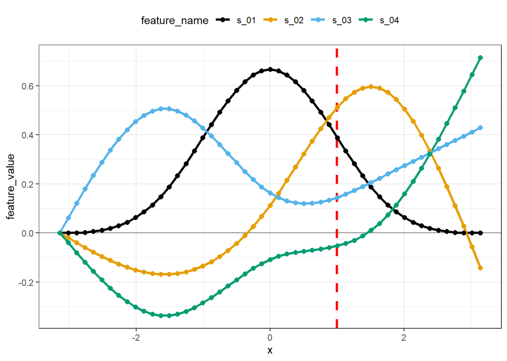

```r
even_basis_04_lf %>%
  ggplot(mapping = aes(x = x, y = feature_value)) +
  geom_hline(yintercept = 0, color = "grey50") +
  geom_vline(xintercept = 1, color = "red", linetype = "dashed",
             size = 1.15) +
  geom_line(mapping = aes(color = feature_name),
            size = 1.15) +
  geom_point(mapping = aes(color = feature_name),
             size = 2) +
  ggthemes::scale_color_colorblind() +
  theme_bw() +
  theme(legend.position = "top")
```

If we would sum together all of the features at `x=2`, all four curves would be added together since all four curves are positive numbers at that input value. The figure below denotes the `x=2` location, similar to the previous figure.

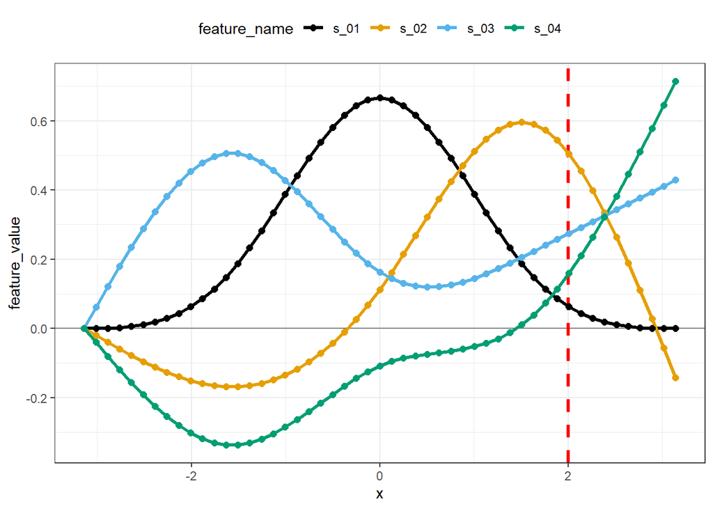

```r
even_basis_04_lf %>%
  ggplot(mapping = aes(x = x, y = feature_value)) +
  geom_hline(yintercept = 0, color = "grey50") +
  geom_vline(xintercept = 2, color = "red", linetype = "dashed",
             size = 1.15) +
  geom_line(mapping = aes(color = feature_name),
            size = 1.15) +
  geom_point(mapping = aes(color = feature_name),
             size = 2) +
  ggthemes::scale_color_colorblind() +
  theme_bw() +
  theme(legend.position = "top")
```

We can sum together the four features at each of the input locations. The code chunk below does that a `group_by()` and subsequent `mutate()` operation to create teh `sum_features` variable. The sum of the four feature is plotted as a red curve in the figure below. Notice how the summed value follows the first feature until about `x=-1`. This represents that the other three features cancel out. After than point the summed value increases until it begins to saturate at 1 by `x=1`. Once the summed value saturates, the features are balancing out as they each continue to change as the input changes.

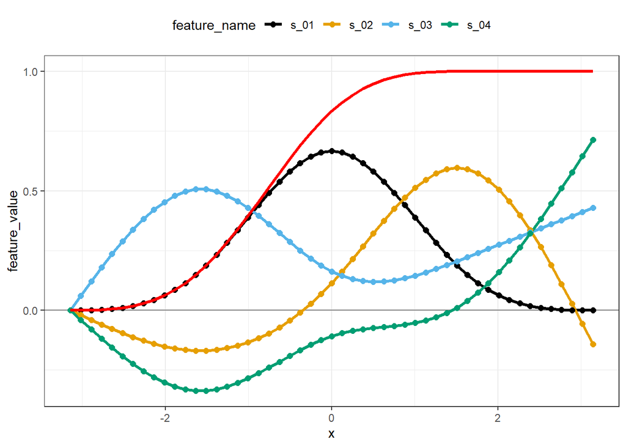

```r
even_basis_04_lf %>%
  group_by(rowid, x) %>%
  mutate(sum_features = sum(feature_value)) %>%
  ungroup() %>%
  ggplot(mapping = aes(x = x, y = feature_value)) +
  geom_hline(yintercept = 0, color = "grey50") +
  geom_line(mapping = aes(color = feature_name),
            size = 1.15) +
  geom_point(mapping = aes(color = feature_name),
             size = 2) +
  geom_line(mapping = aes(y = sum_features),
            color = "red", size = 1.15) +
  ggthemes::scale_color_colorblind() +
  theme_bw() +
  theme(legend.position = "top")
```

If we were to simply sum together the four features from this particular spline basis, all we could approximate would be the s-type curve plotted in red. The intercept would allow us to shift that curve up and down, but clearly the spline basis would have limited use. Splines are however quite flexible. The reason for that is because we are not simply summing together the features. Rather, we will use a weighted sum. Those weights are the coefficients of a linear model!

To see that explicitely, let’s define each feature of the spline basis as $s_{j}\left(x\right)$. The $n$-th observation’s mean trend using the 4 degrees-of-freedom nature spline basis is equal to:

$$\mu_n = \beta_0 + \beta_1 s_{1}\left(x_n\right) + \beta_2 s_{2}\left(x_n\right) + \beta_3 s_{3}\left(x_n\right) + \beta_4 s_{4}\left(x_n\right)$$

Or, written in summation notation by summing over $j=0$ (the intercept, $s_0\left(x\right) = 1$) up to the $J$-th basis feature:

$$\mu_n = \sum_{j=0}^{J} \left( \beta_j s_j\left(x_n\right)\right)$$

Fitting the model requires learning the $J+1$ $\boldsymbol{\beta}$-parameters, just like a linear model consisting of simple additive linear relationships!

Before discussing the fitting procedure though, let’s now see what happens to our basis with the same degrees of freedom if we change the input “locations”. We will repeat the steps to create the 4 degrees-of-freedom natural spline basis, but this time we will use the randomly generated input values. The steps to create `Xmat_norm_04` are shown in the code chunk below.

```r
basis_norm_04 <- splines::ns(norm_df$x, df = 4)

knots_use_norm_04 <- as.vector(attributes(basis_norm_04)$knots)

Xmat_norm_04 <- model.matrix( ~ splines::ns(x, knots = knots_use_norm_04), data = norm_df)

colnames(Xmat_norm_04) <- c(colnames(Xmat_norm_04)[1], sprintf("s_%02d", 1:ncol(basis_norm_04)))
```

Let’s first consider the impact to the location of the knots by changing to the randomly generated input values. The three interior knots are printed to the screen below for the randomly generated input values. Notice that the names are the same as those from the evenly spaced input case. Thus, the three knots are still the 0.25, 0.5, and 0.75 quantiles of the data set. However, because the values were randomly generated from a normal distribution those quantiles will be different from the evenly spaced input values.

```r
attributes(basis_norm_04)$knots
```

```
##        25%        50%        75%
## -0.8397489 -0.4695298  0.3144759
```

The code chunk below reformats the `Xmat_norm_04` design matrix into a long-format and then plots the 4 features with respect to the input `x`. Notice that the shape of the 4 features are very similar to the shapes based on the previous evenly spaced data set. The curves are not as smooth looking though, do to spacing of the input values. We already mentioned that most of the observations are near the mean value of 0. That’s why the extreme points appear to be connected by straight line segments rather than smooth curves; there are simply fewer points located in that interval of the input space.

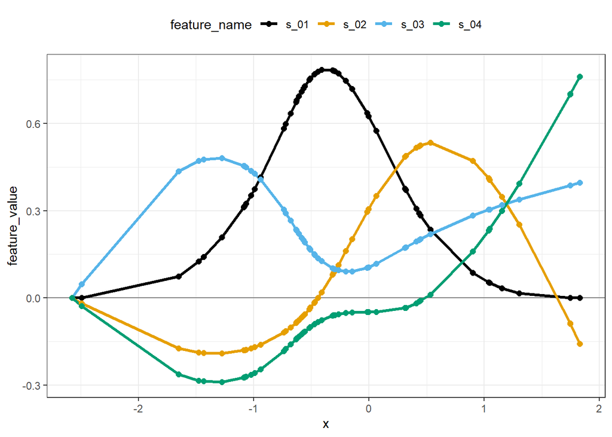

```r
norm_basis_04_lf <- norm_df %>%
  bind_cols(Xmat_norm_04 %>%
              as.data.frame() %>%
              tbl_df()) %>%
  select(-`(Intercept)`) %>%
  tibble::rowid_to_column() %>%
  tidyr::gather(key = "feature_name",
                value = "feature_value",
                -rowid, -x)

norm_basis_04_lf %>%
  ggplot(mapping = aes(x = x, y = feature_value)) +
  geom_hline(yintercept = 0, color = "grey50") +
  geom_line(mapping = aes(color = feature_name),
            size = 1.15) +
  geom_point(mapping = aes(color = feature_name),
             size = 2) +
  ggthemes::scale_color_colorblind() +
  theme_bw() +
  theme(legend.position = "top")
```

Let’s now directly compare the two bases from the two data sets. The code chunk below binds the two long-format data sets together, and adds in a variable to denote the data set the bases are associated with. The resulting combined data set is piped into `ggplot()` where the basis functions are plotted in the same style as previously used. The data sets the bases are associated with are denoted by separate facets. As show below, the shapes are quite similar, but the curves associated with the normally distributed data set are shifted slightly relative to the curves coming from the evenly spaced data set.

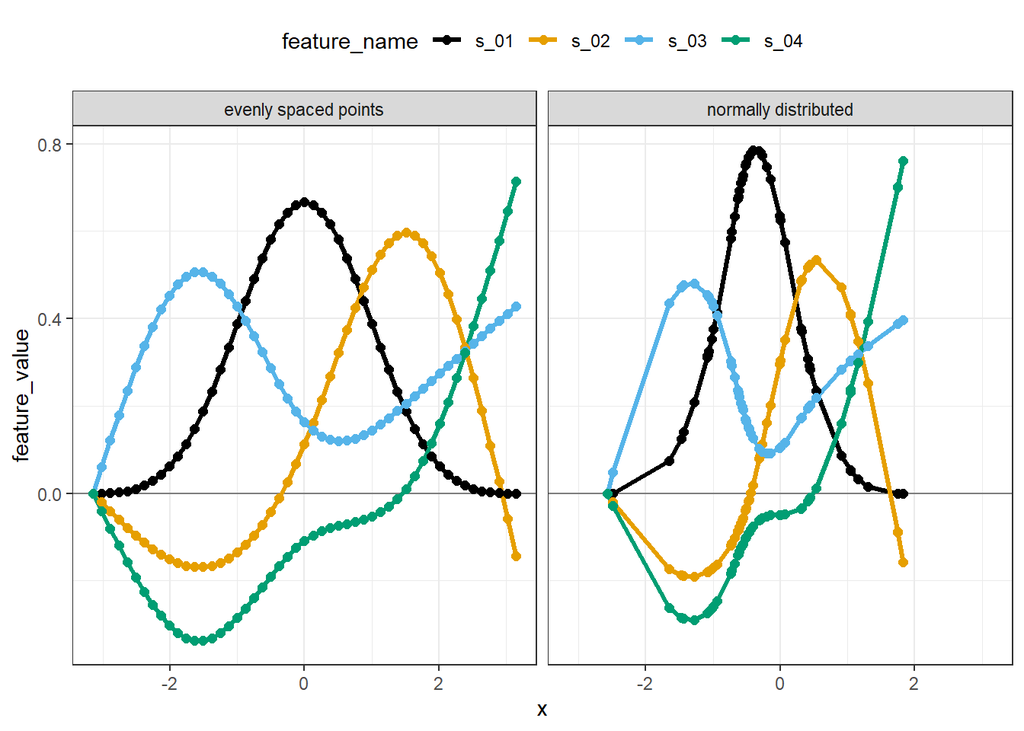

```r
even_basis_04_lf %>%
  mutate(from_data = "evenly spaced points") %>%
  bind_rows(norm_basis_04_lf %>%
              mutate(from_data = "normally distributed")) %>%
  ggplot(mapping = aes(x = x, y = feature_value)) +
  geom_hline(yintercept = 0, color = "grey50") +
  geom_line(mapping = aes(color = feature_name),
            size = 1.15) +
  geom_point(mapping = aes(color = feature_name),
             size = 2) +
  facet_grid( . ~ from_data) +
  ggthemes::scale_color_colorblind() +
  theme_bw() +
  theme(legend.position = "top")
```

The code chunk below provides another comparison between the two data sets. This time the facets correspond to separate basis features, and the colors denote which data set the feature is associated with. As you can see below, the first feature `s_01` represents a bell curve like shape on both data sets. The center and width of that bell curve are different between the two data sets because the input values are different, but the overall shapes are similar. The conclusions are the same for the other features.

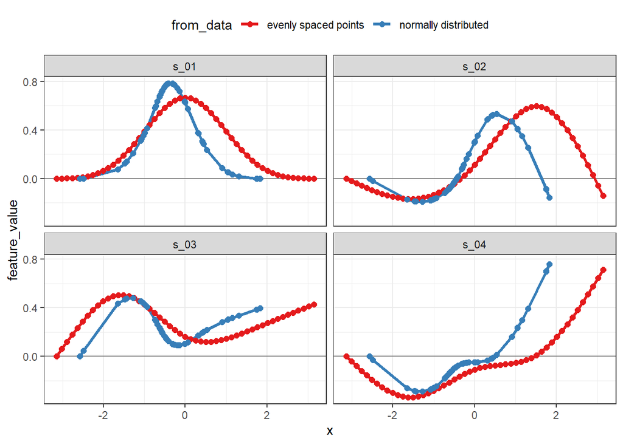

```r
even_basis_04_lf %>%
  mutate(from_data = "evenly spaced points") %>%
  bind_rows(norm_basis_04_lf %>%
              mutate(from_data = "normally distributed")) %>%
  ggplot(mapping = aes(x = x, y = feature_value)) +
  geom_hline(yintercept = 0, color = "grey50") +
  geom_line(mapping = aes(color = from_data),
            size = 1.15) +
  geom_point(mapping = aes(color = from_data),
             size = 2) +
  facet_wrap(~feature_name) +
  scale_color_brewer(palette = "Set1") +
  theme_bw() +
  theme(legend.position = "top")
```

The spline degrees-of-freedom denote a particular set of feature shapes. The data points impact the specific details of those shapes, but the shapes themselves are governed by the degrees-of-freedom. Thus, if we want to try out different shapes, we need to try out a spline with a different level of complexity.

The code chunk below uses `model.matrix()` directly to create the basis design matrix associated splines with 8 degrees-of-freedom for both data sets.

```r
Xmat_even_08 <- model.matrix( ~ splines::ns(x, df = 8), data = even_df)

Xmat_norm_08 <- model.matrix( ~ splines::ns(x, df = 8), data = norm_df)
```

The design matrices are reformatted to long-format in the code chunk below.

```r
even_basis_08_lf <- even_df %>%
  bind_cols(Xmat_even_08 %>%
              as.data.frame() %>%
              tbl_df()) %>%
  select(-`(Intercept)`) %>%
  tibble::rowid_to_column() %>%
  tidyr::gather(key = "feature_name",
                value = "feature_value",
                -rowid, -x)

norm_basis_08_lf <- norm_df %>%
  bind_cols(Xmat_norm_08 %>%
              as.data.frame() %>%
              tbl_df()) %>%
  select(-`(Intercept)`) %>%
  tibble::rowid_to_column() %>%
  tidyr::gather(key = "feature_name",
                value = "feature_value",
                -rowid, -x)
```

Lastly, the features from the two data sets are directly compared below. The shapes of the basis functions are still similar across the two data sets. However, the differences in central tendancy for some of the terms seems greater than the differences for the lower order spline.

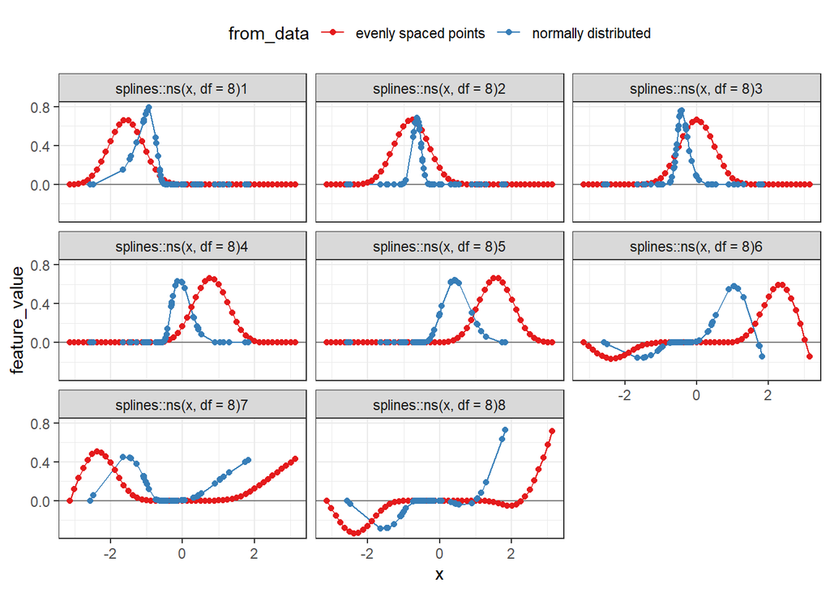

```r
even_basis_08_lf %>%
  mutate(from_data = "evenly spaced points") %>%
  bind_rows(norm_basis_08_lf %>%
              mutate(from_data = "normally distributed")) %>%
  ggplot(mapping = aes(x = x, y = feature_value)) +
  geom_hline(yintercept = 0, color = "grey50") +
  geom_line(mapping = aes(color = from_data)) +
  geom_point(mapping = aes(color = from_data)) +
  facet_wrap(~feature_name) +
  scale_color_brewer(palette = "Set1") +
  theme_bw() +
  theme(legend.position = "top")
```

Now, do the differences between the data sets matter? Well, the configuration of the inputs and thus the design matrix can impact the interpretation of the results. Remember that the posterior covariance between the $\boldsymbol{\beta}$ parameters is related to the design matrix sum-of-squares matrix:

$$\mathrm{cov}\left(\boldsymbol{\beta}, \boldsymbol{\beta}\right) \propto \left( \mathbf{X}^T\mathbf{X} \right)^{-1}$$

Let’s calculate the inverse of the sum-of-squares matrix for 4 degrees-of-freedom splines associated with both data sets.

```r
inv_ssmat_even_04 <- solve(t(Xmat_even_04) %*% Xmat_even_04)

inv_ssmat_norm_04 <- solve(t(Xmat_norm_04) %*% Xmat_norm_04)
```

These matrices represent the covariance between the parameters, so we can convert them to correlation matrices to get an idea about how correlated the parameters will be.

```r
cov2cor(inv_ssmat_even_04)
```

```
##             (Intercept)        s_01        s_02         s_03         s_04
## (Intercept)  1.00000000 -0.51830781 -0.55347404 -0.919155651 -0.030598256
## s_01        -0.51830781  1.00000000 -0.05590832  0.308444906  0.427411629
## s_02        -0.55347404 -0.05590832  1.00000000  0.530896978 -0.363432824
## s_03        -0.91915565  0.30844491  0.53089698  1.000000000 -0.002482579
## s_04        -0.03059826  0.42741163 -0.36343282 -0.002482579  1.000000000
```

```r
cov2cor(inv_ssmat_norm_04)
```

```
##             (Intercept)       s_01        s_02       s_03        s_04
## (Intercept)   1.0000000 -0.8703419 -0.58901371 -0.9263067 -0.32750025
## s_01         -0.8703419  1.0000000  0.39500913  0.6967152  0.47860074
## s_02         -0.5890137  0.3950091  1.00000000  0.5810608 -0.06713418
## s_03         -0.9263067  0.6967152  0.58106084  1.0000000  0.26005714
## s_04         -0.3275002  0.4786007 -0.06713418  0.2600571  1.00000000
```

Since the print out can be a little difficult to read, let’s visualize the correlation matrices with `corrplot`. The posterior correlation matrix for the evenly spaced points is shown below. Notice that the highest correlation is between the intercept and the 3rd basis feature, at -0.92.

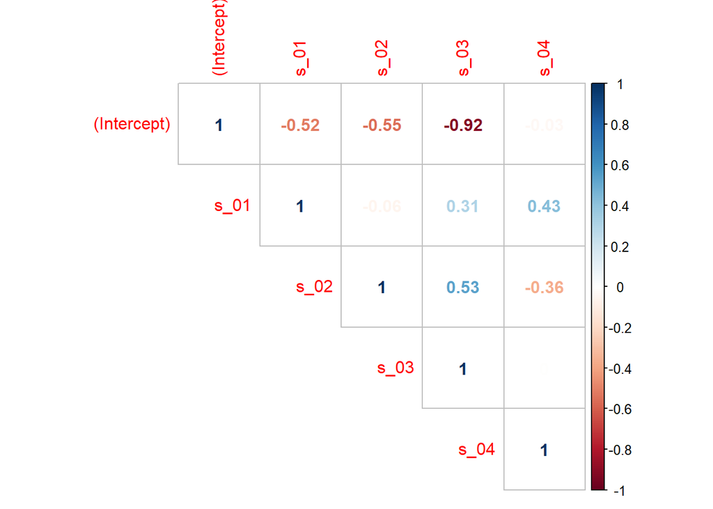

```r
cov2cor(inv_ssmat_even_04) %>%
  corrplot::corrplot(type = "upper", method = "number")
```

The posterior correlation matrix for the randomly generated inputs is shown below. We can see that the intercept is also highly anti-correlated with the 3rd basis feature, but the intercept is also highly anti-correlated with the first basis feature!

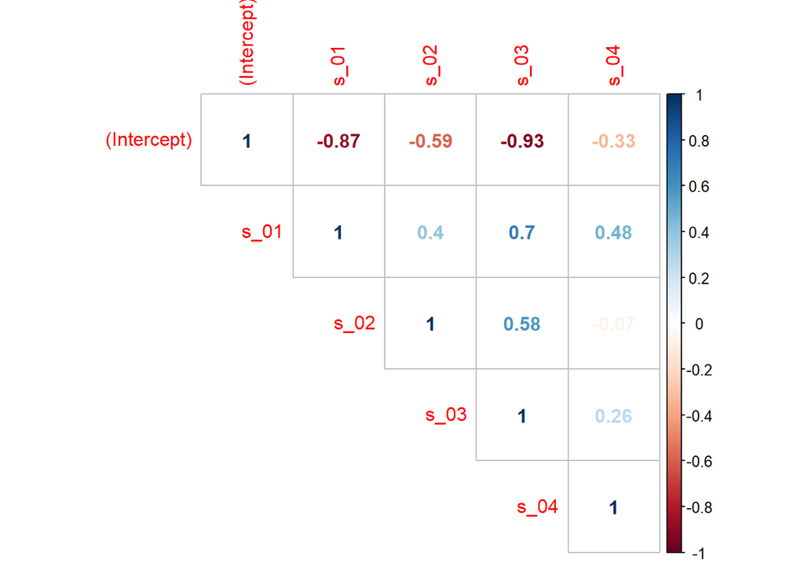

```r
cov2cor(inv_ssmat_norm_04) %>%
  corrplot::corrplot(type = "upper", method = "number")
```

The input “configuration” impacts the interpretation of the model fitting results. However, with splines we are less interested in intepreting the basis “effects” and more interested in smoothing non-linear trends. To that end, let’s apply the natural spline basis to the a modeling task.

### Sine-wave output

Let’s take the evenly spaced data points and generate noisy observations around a sine-wave. The likelihood noise, $\sigma$, will be set to be 0.15.

```r
set.seed(51231)
even_data <- even_df %>%
  mutate(mu = sin(x),
         y = rnorm(n = n(), mean = mu, sd = 0.15))
```

The noisy inputs are plotted relative to the true sine-wave in the figure below.

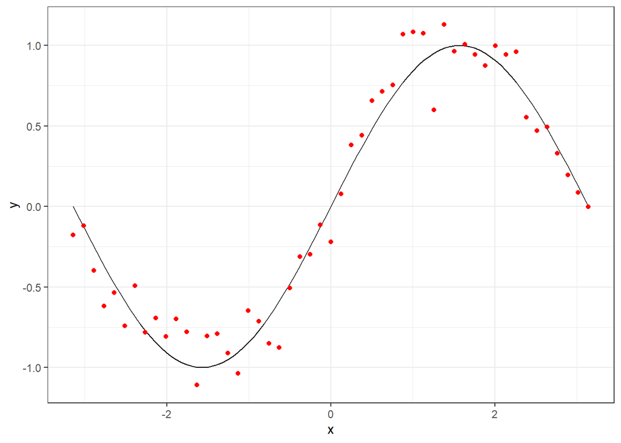

```r
even_data %>%
  ggplot(mapping = aes(x = x)) +
  stat_function(fun = sin,
                color = "black") +
  geom_point(mapping = aes(y = y),
             color = "red") +
  theme_bw()
```

We could fit a Bayesian linear model using the framework introduced in lecture. However, let’s just get some ideas about the behavior of the approach. So we will use non-Bayesian techniques in this report. It’s straight forward to fit a non-Bayesian linear model with a spline basis to these noisy observations. We already saw what the basis functions look like, so we will fit the model directly with the `lm()` function. We can use the formula interface to specify the spline basis directly to the linear model.

```r
fit_even_04_sine <- lm(y ~ splines::ns(x, df = 4), data = even_data)
```

The summary of the spline model fit is printed below.

```r
fit_even_04_sine %>% summary()
```

```
##
## Call:
## lm(formula = y ~ splines::ns(x, df = 4), data = even_data)
##
## Residuals:
##      Min       1Q   Median       3Q      Max
## -0.41807 -0.09238  0.01569  0.11905  0.27345
##
## Coefficients:
##                         Estimate Std. Error t value Pr(>|t|)
## (Intercept)             -0.14767    0.07877  -1.875   0.0672 .
## splines::ns(x, df = 4)1  0.05048    0.10312   0.490   0.6268
## splines::ns(x, df = 4)2  2.15302    0.10150  21.211  < 2e-16 ***
## splines::ns(x, df = 4)3 -0.35818    0.20251  -1.769   0.0836 .
## splines::ns(x, df = 4)4  0.73670    0.09433   7.810 5.65e-10 ***
## ---
## Signif. codes:  0 '***' 0.001 '**' 0.01 '*' 0.05 '.' 0.1 ' ' 1
##
## Residual standard error: 0.1492 on 46 degrees of freedom
## Multiple R-squared:  0.9608, Adjusted R-squared:  0.9574
## F-statistic: 281.8 on 4 and 46 DF,  p-value: < 2.2e-16
```

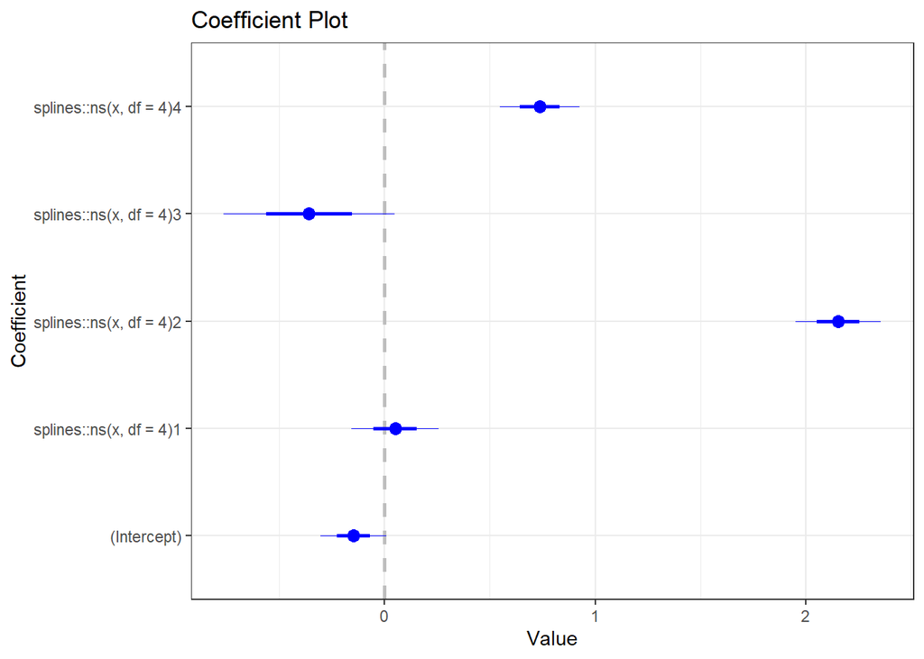

```r
coefplot::coefplot(fit_even_04_sine) + theme_bw()
```

Let’s show that is indeed the case by overlaying the weighted sum of the 4 features with the basis features themselves. The code chunk below organizes the coefficients into a data.frame for the feature weights. Then merges that with the long-format feature object `even_basis_04_lf`. This allows directly comparing the non-weighted summed features with the weighted sum of the features. Note that, we are focused on the summation excluding the intercept just to be consistent with the figures from the beginning of the report. The non-weighted sum of the four features is still shown by the red curve. The weighted sum, based on the coefficients from the fit linear model, is displayed by the navy blue curve. The weights now change how the 4 features are summed together, producing a curve that looks like a sine wave, rather than the s-shaped red curve.

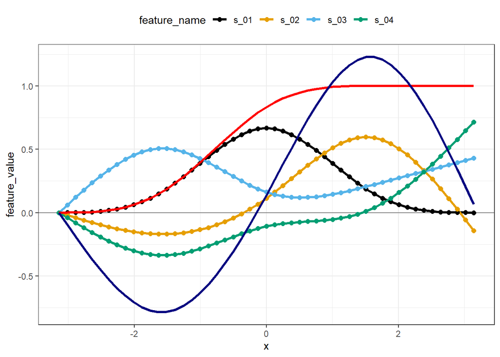

```r
weights_even_04_sine <- tibble::tibble(
  w = as.vector(coef(fit_even_04_sine)[-1])
) %>%
  tibble::rowid_to_column("feature_id") %>%
  mutate(feature_name = sprintf("s_%02d", feature_id))

even_basis_04_lf %>%
  left_join(weights_even_04_sine %>%
              select(w, feature_name),
            by = "feature_name") %>%
  group_by(rowid, x) %>%
  mutate(sum_features = sum(feature_value),
         weight_sum = sum(w * feature_value)) %>%
  ungroup() %>%
  ggplot(mapping = aes(x = x, y = feature_value)) +
  geom_hline(yintercept = 0, color = "grey50") +
  geom_line(mapping = aes(color = feature_name),
            size = 1.15) +
  geom_point(mapping = aes(color = feature_name),
             size = 2) +
  geom_line(mapping = aes(y = sum_features),
            color = "red", size = 1.15) +
  geom_line(mapping = aes(y = weight_sum),
            color = "navyblue", size = 1.15) +
  ggthemes::scale_color_colorblind() +
  theme_bw() +
  theme(legend.position = "top")
```

### Cosine-wave output

The benefit of splines are the flexibility of the basis to easily adapt to different outputs. We can apply the same basis to a different function. Fitting the model to a different data set, and thus relearning the weights applied to each basis feature changes how the features are summed together. Let’s demonstrate this by generating noisy observations of a cosine wave.

```r
set.seed(51231)
even_data_cos <- even_df %>%
  mutate(mu = cos(x),
         y = rnorm(n = n(), mean = mu, sd = 0.15))
```

The evenly spaced input values were used, but by using the cosine instead of the sine the data are different from before.

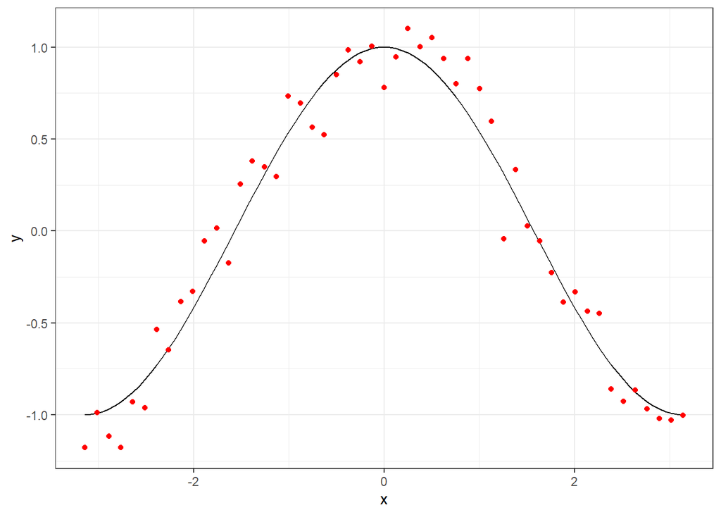

```r
even_data_cos %>%
  ggplot(mapping = aes(x = x)) +
  stat_function(fun = cos,
                color = "black") +
  geom_point(mapping = aes(y = y),
             color = "red") +
  theme_bw()
```

Fitting the non-Bayesian model is again straight forward to do, We can reuse the same formula. We just need to change the data!

```r
fit_even_04_cos <- lm(y ~ splines::ns(x, df = 4), data = even_data_cos)
```

Inspecting the coefficients of the model reveals that none of the features are now essentially zero. The first feature now has the largest absolute value, with a coefficient of nearly 3.

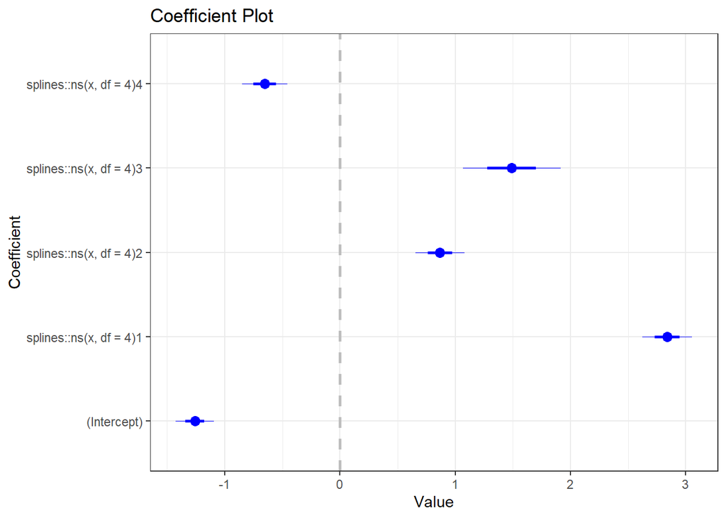

```r
coefplot::coefplot(fit_even_04_cos) + theme_bw()
```

Let’s now apply the learned maximum likelihood estimate (MLE) coefficient values to the 4 basis features again and compare to the non-weighted sum. The weighted sum of the 4 basis features is shown by the blue curve in the graph below. Again this figure neglects the intercept, which would shift the blue curve down if applied. By using different coefficient values, we have altered the result of the weighted sum of the 4 features compared to what we had last time!

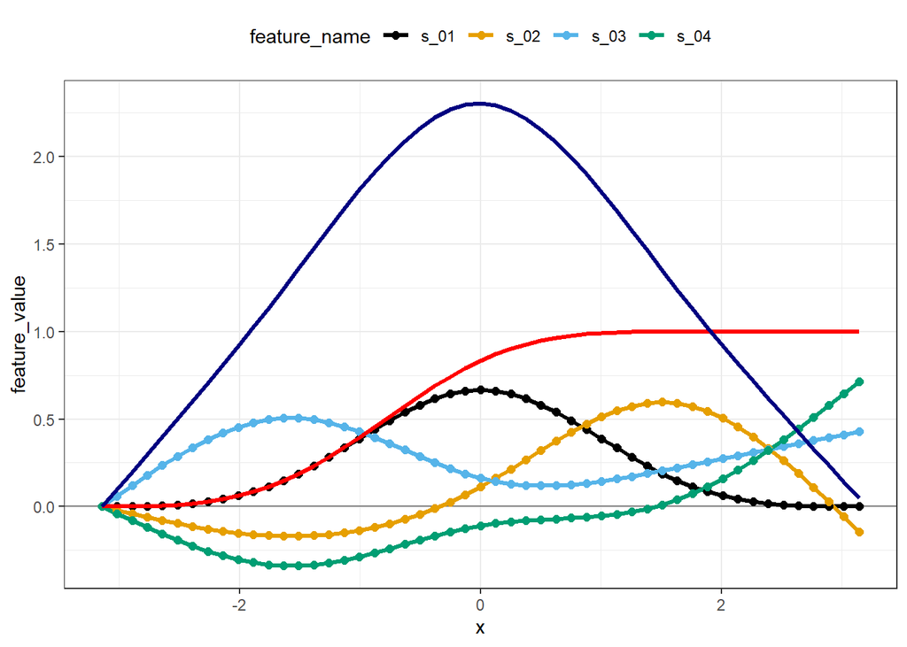

```r
weights_even_04_cos <- tibble::tibble(
  w = as.vector(coef(fit_even_04_cos)[-1])
) %>%
  tibble::rowid_to_column("feature_id") %>%
  mutate(feature_name = sprintf("s_%02d", feature_id))

even_basis_04_lf %>%
  left_join(weights_even_04_cos %>%
              select(w, feature_name),
            by = "feature_name") %>%
  group_by(rowid, x) %>%
  mutate(sum_features = sum(feature_value),
         weight_sum = sum(w * feature_value)) %>%
  ungroup() %>%
  ggplot(mapping = aes(x = x, y = feature_value)) +
  geom_hline(yintercept = 0, color = "grey50") +
  geom_line(mapping = aes(color = feature_name),
            size = 1.15) +
  geom_point(mapping = aes(color = feature_name),
             size = 2) +
  geom_line(mapping = aes(y = sum_features),
            color = "red", size = 1.15) +
  geom_line(mapping = aes(y = weight_sum),
            color = "navyblue", size = 1.15) +
  ggthemes::scale_color_colorblind() +
  theme_bw() +
  theme(legend.position = "top")
```